# ML_Types

### Task 2 (d):

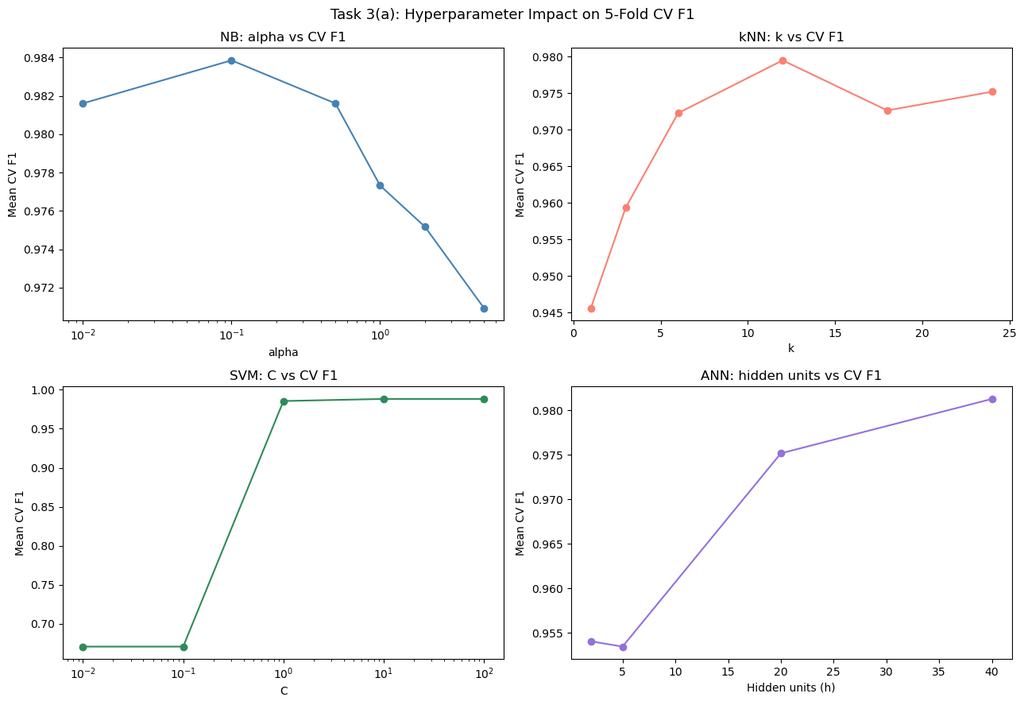

```
Best NB alpha: 0.1 (F1=0.9839)
Best kNN k: 12 (F1=0.9795)
Best SVM C: 10 (F1=0.9883)
Best ANN h: 40 (F1=0.9813)

Task 3(b): Test set F1 scores with best hyperparameters
Naive Bayes      F1 = 0.9677
kNN              F1 = 0.9778
SVM              F1 = 0.9890
ANN              F1 = 0.9890
```

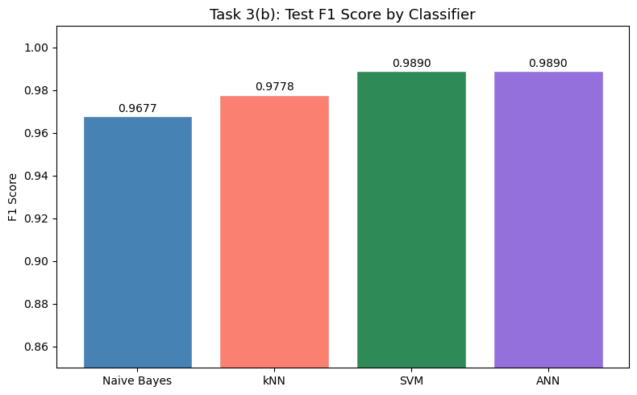

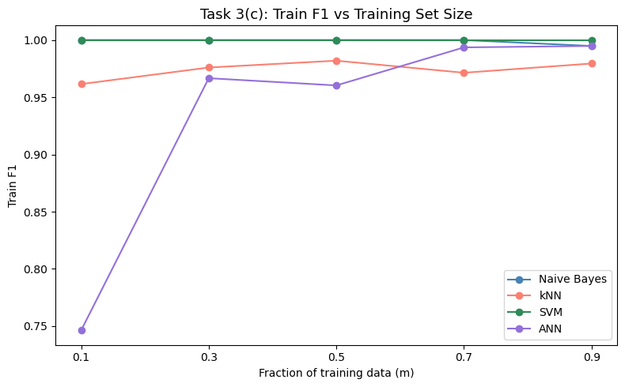

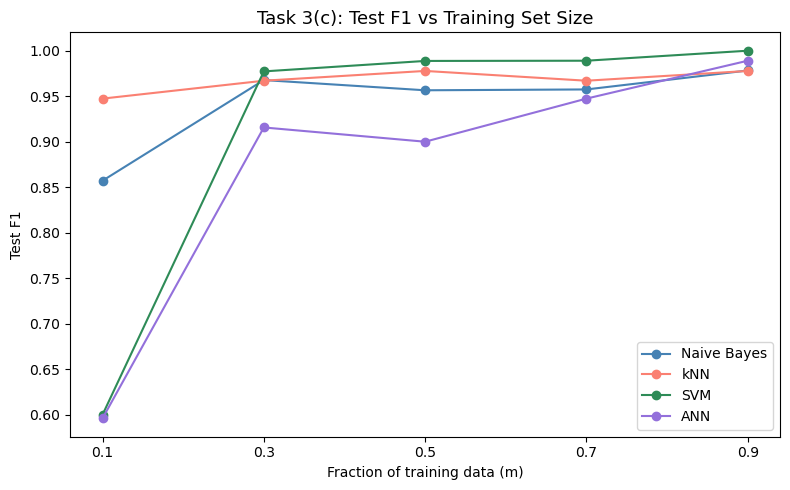

```python
#TASK 3: Classification Quality Evaluation

from sklearn.model_selection import cross_val_score
from sklearn.metrics import f1_score

# Task 3(a): Hyperparameter investigation using 5-fold cross-validation

#Naive Bayes: alpha (Laplace smoothing)
nb_alphas = [0.01, 0.1, 0.5, 1.0, 2.0, 5.0]
nb_cv_scores = [cross_val_score(MultinomialNB(alpha= a), X_train, y_train, cv = 5, scoring = 'f1').mean() for a in nb_alphas]

#kNN: adjusting number of neighbours k
knn_ks = [1, 3, 6, 12, 18, 24]
knn_cv_scores = [cross_val_score(KNeighborsClassifier(n_neighbors = k), X_train, y_train, cv = 5, scoring ='f1').mean() for k in knn_ks]

#SVM: regularisation parameter C (linear kernel)
#Low C = wide margin, more misclassifications allowed (underfitting)
#High C = narrow margin, fewer misclassifications (risk of overfitting)
svm_Cs = [0.01, 0.1, 1, 10, 100]
svm_cv_scores = [cross_val_score(SVC(kernel = 'rbf', C = c, gamma = 0.1), X_train, y_train, cv = 5, scoring = 'f1').mean() for c in svm_Cs]

#ANN: number of hidden units h
#More units = more capacity to learn complex patterns, but may overfit
ann_hs = [2, 5, 20, 40]
ann_cv_scores = [cross_val_score(MLPClassifier(hidden_layer_sizes = (h,), solver = 'sgd', learning_rate_init = 0.01, max_iter = 100, random_state= 42),X_train, y_train, cv=5, scoring='f1').mean() for h in ann_hs]

#Plot all four hyperparameter sweeps
fig, axes = plt.subplots(2, 2, figsize = (13, 9))

axes[0, 0].plot(nb_alphas, nb_cv_scores, marker = 'o', color= 'steelblue')
axes[0, 0].set_title('NB: alpha vs CV F1')
axes[0, 0].set_xlabel('alpha')
axes[0, 0].set_ylabel('Mean CV F1')
axes[0, 0].set_xscale('log')

axes[0, 1].plot(knn_ks, knn_cv_scores, marker = 'o', color = 'salmon')
axes[0, 1].set_title('kNN: k vs CV F1')
axes[0, 1].set_xlabel('k')
axes[0, 1].set_ylabel('Mean CV F1')

axes[1, 0].plot(svm_Cs, svm_cv_scores, marker = 'o', color = 'seagreen')
axes[1, 0].set_title('SVM: C vs CV F1')
axes[1, 0].set_xlabel('C')
axes[1, 0].set_ylabel('Mean CV F1')
axes[1, 0].set_xscale('log')

axes[1, 1].plot(ann_hs, ann_cv_scores, marker = 'o', color = 'mediumpurple')
axes[1, 1].set_title('ANN: hidden units vs CV F1')
axes[1, 1].set_xlabel('Hidden units (h)')
axes[1, 1].set_ylabel('Mean CV F1')

plt.suptitle('Task 3(a): Hyperparameter Impact on 5-Fold CV F1', fontsize=13)
plt.tight_layout()
plt.savefig('task3a_hyperparameters.png', dpi=120)
plt.show()

# Print best values
print(f"Best NB alpha: {nb_alphas[np.argmax(nb_cv_scores)]} (F1={max(nb_cv_scores):.4f})")
print(f"Best kNN k: {knn_ks[np.argmax(knn_cv_scores)]} (F1={max(knn_cv_scores):.4f})")
print(f"Best SVM C: {svm_Cs[np.argmax(svm_cv_scores)]} (F1={max(svm_cv_scores):.4f})")
print(f"Best ANN h: {ann_hs[np.argmax(ann_cv_scores)]} (F1={max(ann_cv_scores):.4f})")


#Task 3(b): Compare best models on the test set using F1 score

#Best hyperparameters from 3(a)
best_models = {
    'Naive Bayes': MultinomialNB(alpha =0.1),
    'kNN': KNeighborsClassifier(n_neighbors = 10),
    'SVM': SVC(kernel = 'rbf', C = 1),
    'ANN': MLPClassifier(hidden_layer_sizes = (40,), solver='sgd', learning_rate_init = 0.01, max_iter = 100, random_state = 42)
}

print("\nTask 3(b): Test set F1 scores with best hyperparameters")
test_f1_results = {}
for name, clf in best_models.items():
    clf.fit(X_train, y_train)
    f1 = f1_score(y_test, clf.predict(X_test))
    test_f1_results[name] = f1
    print(f"{name:15s}  F1 = {f1:.4f}")

#Bar chart comparison
fig, ax = plt.subplots(figsize = (8, 5))
colors = ['steelblue', 'salmon', 'seagreen', 'mediumpurple']
bars = ax.bar(test_f1_results.keys(), test_f1_results.values(), color = colors, edgecolor = 'white')
ax.set_ylim(0.85, 1.01)
ax.set_title('Task 3(b): Test F1 Score by Classifier', fontsize=13)
ax.set_ylabel('F1 Score')
for bar, val in zip(bars, test_f1_results.values()):
    ax.text(bar.get_x() + bar.get_width() / 2, bar.get_height() + 0.002, f'{val:.4f}', ha='center', fontsize=10)
plt.tight_layout()
plt.savefig('task3b_test_f1.png', dpi=120)
plt.show()


#Task 3(c): Effect of training set size

#For each fraction m of the training data, train on data[0 : int(m * N)] and evaluate F1 on both the training slice and the full test set
ms = [0.1, 0.3, 0.5, 0.7, 0.9]
N = X_train.shape[0]

train_f1s = {name: [] for name in best_models}
test_f1s = {name: [] for name in best_models}

for m in ms:
    n = int(m * N)
    Xm = X_train[:n]
    ym = y_train[:n]
    for name, clf in best_models.items():
        clf.fit(Xm, ym)
        train_f1s[name].append(f1_score(ym, clf.predict(Xm)))
        test_f1s[name].append(f1_score(y_test, clf.predict(X_test)))

colors_map = {
    'Naive Bayes': 'steelblue',
    'kNN': 'salmon',
    'SVM': 'seagreen',
    'ANN': 'mediumpurple'
}

#Plot (i): Training F1 score vs m
fig, ax = plt.subplots(figsize=(8, 5))
for name in best_models:
    ax.plot(ms, train_f1s[name], marker='o', label=name, color = colors_map[name])
ax.set_title('Task 3(c): Train F1 vs Training Set Size', fontsize = 13)
ax.set_xlabel('Fraction of training data (m)')
ax.set_ylabel('Train F1')
ax.set_xticks(ms)
ax.legend()
plt.tight_layout()
plt.savefig('task3c_train_f1.png', dpi = 120)
plt.show()

#Plot (ii): Testing F1 score vs m
fig, ax = plt.subplots(figsize = (8, 5))
for name in best_models:
    ax.plot(ms, test_f1s[name], marker = 'o', label = name, color = colors_map[name])
ax.set_title('Task 3(c): Test F1 vs Training Set Size', fontsize = 13)
ax.set_xlabel('Fraction of training data (m)')
ax.set_ylabel('Test F1')
ax.set_xticks(ms)
ax.legend()
plt.tight_layout()
plt.savefig('task3c_test_f1.png', dpi=120)
plt.show()
```

### Task 3 (a):

- NB: F1 score peaks at a small alpha (0.1) and drops as alpha grows, because heavy smoothing makes word probabilities less discriminative.
- kNN: F1 score rises initially then levels off since very small k (k=1) memorizes the data and overfits while very large k may generealize too broadly and underfit. k = 12 gives the best balance between bias and variance.
- SVM: F1 score is very low at C = 0.01 because the model is underfit. It then plateaus from C = 1 onwards because a RBF kernel already separates the classes well, so pushing C higher gives no further gain.
- ANN: F1 score increases with h becasue larger networks have more capacity to fit the data. Gains begin slow beyond h = 20, but continue to grow as we increase h to its maximum value of 40 where we have the best performance.

### Task 3(c):

Train F1:

- NB and SVM perform perfectly on the training data even at small m because they can become an exact fit to the data. kNN gets F1 = 1.0 at k = 1 because it memorises training points. Here, k = 10 so the F1 score is slightly below 1, but kNN is able to effectively separate data points even at small m. ANN performs poorly at small m because the network hasn't seen enough data to learn helpful patterns, but climbs as m grows.

Test F1: